# Table of Contents

**Group Name:** Group 1

**Group Members**:

- Hritik Tayade (s38033067)
- Rujuta Mokashi(s3827722)

# INTRODUCTION

In any E-Commerce business, it is necessary for the products to be delivered on time. This marks one of the criterias of customer satisfaction and the ratings given by the customer for the company. The delivery time of a product depends on the block of Warehouse from where the product leaves to the mode of transportation depending on the importance of the product.

In this report we have used an E-Commerece Shipping data of an International company, that sells electronic products and is interested in the key insights from their customer database(Kaggle,2021). The dataset can be accessed from [here](https://www.kaggle.com/prachi13/customer-analytics) which contains 12 feaures and 11000 observations.  
The features of the dataset are as follows:

| Feature Name | Data Type | Units | Description |  |
| --- | --- | --- | --- | --- |
| ID | Integer | NA | NA | ID Number of Customers |
| Warehouse block | Nominal | NA | The Company has big Warehouse which is divided in to block such as A,B,C,D,E. |  |
| Mode of shipment | Nominal | NA | The Company Ships the products in multiple way such as Ship, Flight and Road. |  |
| Customer care calls | Interger | NA | The number of calls made from enquiry for enquiry of the shipment. |  |
| Customer rating | Interger | NA | The company has rated from every customer. 1 is the lowest, 5 is the highest (Best) |  |
| Cost of the product | Interger | U.S Dollar | Cost of the Product in US Dollars |  |
| Prior purchases | Interger | NA | The Number of Prior Purchase |  |
| Product importance | Ordinal | NA | The company has categorized the product in the various parameter such as low, medium, high |  |
| Gender | Nominal | NA | Male and Female |  |
| Discount offered | Interger | U.S. Dollar | Discount offered on that specific product. |  |
| Weight in gms | Interger | Grams | It is the weight in grams |  |
| Reached on time | Interger | NA | It is the target variable, where 1 Indicates that the product has not reached on time and 0 indicates it has reached on time |  |

The report contains visualizations of various features and their correlations between them with the target variable being `Reached_on_Time` for the analysis and modelling. We will be using these features to predict if the products would reach on time or not.

## Report Overview

In this report we develop various Machine Learning models, train them on the training data and evaluate their performances on both train and test data. For each model, a set of features are selected using various feature selection techniques discussed in the later section.Also, for each feature selection technique their performance score is evaluated before passing them to different models. For the dataset in consideration, we have used `KNN`, `Decision Tree`, `Naive Bayes` and `Random Forest` models which are fitted on the selected features, trained and tuned for various paramaters respectively.Towards the end of the report, the performance of each model on the test data along with the limitations of the approach used for developing those models is discussed.  
Finally, the report is summarised with our findings on prediction of a product reaching on time and how the aptness of the meothodology aligns with our goals and objectives for the E-Commerece Business.

## Overview of Methodology

In this section, we first pre-process the data, splitting the data into feature and target dataframes. Next, we label encode the feature dataframe using get.dummies() function and scale it usinng the MinMaxScaler() function to finally split the data into train and test sets.These train and test sets are used in the predictive modelling section. In the predictive modelling section, feature selection is performed using `fscore`, `Mutual Information` and `Random Forest Importance` techniques. The performance of each feature selection technique is evaluated to select the best performing technique and use those feeatures obtained from the selected method are split into train and test sets for modelling.  
Post feature selection, the train data is used for modelling `KNN`, `Decision Tree`, `Naive Bayes` and `Random Forest` classifiers, tunning the paramters for each model and evaluating their performances. The preformance of each model is compared on the test data based on the which the model with greater accuracy and efficiency is selected for making predictions.

```python
#Importing required packages.
```

```python
import pandas as pd
import seaborn as sns
import matplotlib.pyplot as plt
import warnings
import numpy as np
import os
from sklearn import preprocessing, metrics
from sklearn import feature_selection as fs
from sklearn.model_selection import train_test_split
from sklearn.tree import DecisionTreeClassifier
from sklearn.model_selection import cross_val_score, StratifiedKFold,GridSearchCV,RepeatedStratifiedKFold
from sklearn import feature_selection as fs
from sklearn.ensemble import RandomForestClassifier
from sklearn.neighbors import KNeighborsClassifier
```

```python
os.chdir(r'C:\Users\rujut\Desktop\ML Project')
```

```python
#Import data
prod_info = pd.read_csv('Warehouse.csv')

#Display the first 5 rows of the dataset
#Dropping the ID column from the dataset.prod_info.head()
```

```python
#Dropping the ID column from the dataset.
prod_info.drop(['ID'],axis=1,inplace=True)

#Renaming the "Reached.on.Time_Y.N" column.
clean_data = prod_info.rename(columns={"Reached.on.Time_Y.N": "Reached_On_Time"})
```

```python
#Displaying the first 5 rows of the clean data
clean_data.head()
```

|  | Warehouse_block | Mode_of_Shipment | Customer_care_calls | Customer_rating | Cost_of_the_Product | Prior_purchases | Product_importance | Gender | Discount_offered | Weight_in_gms | Reached_On_Time |
| --- | --- | --- | --- | --- | --- | --- | --- | --- | --- | --- | --- |
| 0 | D | Flight | 4 | 2 | 177 | 3 | low | F | 44 | 1233 | 1 |
| 1 | F | Flight | 4 | 5 | 216 | 2 | low | M | 59 | 3088 | 1 |
| 2 | A | Flight | 2 | 2 | 183 | 4 | low | M | 48 | 3374 | 1 |
| 3 | B | Flight | 3 | 3 | 176 | 4 | medium | M | 10 | 1177 | 1 |
| 4 | C | Flight | 2 | 2 | 184 | 3 | medium | F | 46 | 2484 | 1 |

```python
#Dropping the "Reached_On_Time" column to make the feautre dataframe.
product_data = clean_data.drop(columns = 'Reached_On_Time')

#Making a target_feature dataframe using "Reached_On_Time" column.
target_feature = clean_data['Reached_On_Time']
```

```python
#Displaying the product_data
product_data
```

|  | Warehouse_block | Mode_of_Shipment | Customer_care_calls | Customer_rating | Cost_of_the_Product | Prior_purchases | Product_importance | Gender | Discount_offered | Weight_in_gms |
| --- | --- | --- | --- | --- | --- | --- | --- | --- | --- | --- |
| 0 | D | Flight | 4 | 2 | 177 | 3 | low | F | 44 | 1233 |
| 1 | F | Flight | 4 | 5 | 216 | 2 | low | M | 59 | 3088 |
| 2 | A | Flight | 2 | 2 | 183 | 4 | low | M | 48 | 3374 |
| 3 | B | Flight | 3 | 3 | 176 | 4 | medium | M | 10 | 1177 |
| 4 | C | Flight | 2 | 2 | 184 | 3 | medium | F | 46 | 2484 |
| ... | ... | ... | ... | ... | ... | ... | ... | ... | ... | ... |
| 10994 | A | Ship | 4 | 1 | 252 | 5 | medium | F | 1 | 1538 |
| 10995 | B | Ship | 4 | 1 | 232 | 5 | medium | F | 6 | 1247 |
| 10996 | C | Ship | 5 | 4 | 242 | 5 | low | F | 4 | 1155 |
| 10997 | F | Ship | 5 | 2 | 223 | 6 | medium | M | 2 | 1210 |
| 10998 | D | Ship | 2 | 5 | 155 | 5 | low | F | 6 | 1639 |

10999 rows × 10 columns

```python
#Getting dummies for the product_data dataframe
prod_data = pd.get_dummies(product_data)
prod_data
```

|  | Customer_care_calls | Customer_rating | Cost_of_the_Product | Prior_purchases | Discount_offered | Weight_in_gms | Warehouse_block_A | Warehouse_block_B | Warehouse_block_C | Warehouse_block_D | Warehouse_block_F | Mode_of_Shipment_Flight | Mode_of_Shipment_Road | Mode_of_Shipment_Ship | Product_importance_high | Product_importance_low | Product_importance_medium | Gender_F | Gender_M |
| --- | --- | --- | --- | --- | --- | --- | --- | --- | --- | --- | --- | --- | --- | --- | --- | --- | --- | --- | --- |
| 0 | 4 | 2 | 177 | 3 | 44 | 1233 | 0 | 0 | 0 | 1 | 0 | 1 | 0 | 0 | 0 | 1 | 0 | 1 | 0 |
| 1 | 4 | 5 | 216 | 2 | 59 | 3088 | 0 | 0 | 0 | 0 | 1 | 1 | 0 | 0 | 0 | 1 | 0 | 0 | 1 |
| 2 | 2 | 2 | 183 | 4 | 48 | 3374 | 1 | 0 | 0 | 0 | 0 | 1 | 0 | 0 | 0 | 1 | 0 | 0 | 1 |
| 3 | 3 | 3 | 176 | 4 | 10 | 1177 | 0 | 1 | 0 | 0 | 0 | 1 | 0 | 0 | 0 | 0 | 1 | 0 | 1 |
| 4 | 2 | 2 | 184 | 3 | 46 | 2484 | 0 | 0 | 1 | 0 | 0 | 1 | 0 | 0 | 0 | 0 | 1 | 1 | 0 |
| ... | ... | ... | ... | ... | ... | ... | ... | ... | ... | ... | ... | ... | ... | ... | ... | ... | ... | ... | ... |
| 10994 | 4 | 1 | 252 | 5 | 1 | 1538 | 1 | 0 | 0 | 0 | 0 | 0 | 0 | 1 | 0 | 0 | 1 | 1 | 0 |
| 10995 | 4 | 1 | 232 | 5 | 6 | 1247 | 0 | 1 | 0 | 0 | 0 | 0 | 0 | 1 | 0 | 0 | 1 | 1 | 0 |
| 10996 | 5 | 4 | 242 | 5 | 4 | 1155 | 0 | 0 | 1 | 0 | 0 | 0 | 0 | 1 | 0 | 1 | 0 | 1 | 0 |
| 10997 | 5 | 2 | 223 | 6 | 2 | 1210 | 0 | 0 | 0 | 0 | 1 | 0 | 0 | 1 | 0 | 0 | 1 | 0 | 1 |
| 10998 | 2 | 5 | 155 | 5 | 6 | 1639 | 0 | 0 | 0 | 1 | 0 | 0 | 0 | 1 | 0 | 1 | 0 | 1 | 0 |

10999 rows × 19 columns

```python
#Scaling the prod_data using MinMaxScaler function
scaled_data = preprocessing.MinMaxScaler().fit_transform(prod_data)

#Displaying the scaled data
scaled_data
```

```
array([[0.4       , 0.25      , 0.37850467, ..., 0.        , 1.        ,
        0.        ],
       [0.4       , 1.        , 0.56074766, ..., 0.        , 0.        ,
        1.        ],
       [0.        , 0.25      , 0.40654206, ..., 0.        , 0.        ,
        1.        ],
       ...,
       [0.6       , 0.75      , 0.68224299, ..., 0.        , 1.        ,
        0.        ],
       [0.6       , 0.25      , 0.59345794, ..., 1.        , 0.        ,
        1.        ],
       [0.        , 1.        , 0.27570093, ..., 0.        , 1.        ,
        0.        ]])
```

```python
#Splitting the data into train_test_split
D_train, D_test, t_train, t_test = train_test_split(scaled_data, target_feature, test_size=0.3, random_state=999)
```

```python
#Displaying the shape of train and test sets

print(D_train.shape)
print(D_test.shape)
print(t_train.shape)
print(t_test.shape)
```

```
(7699, 19)
(3300, 19)
(7699,)
(3300,)
```

```python
#Displaying the target feature
target_feature
```

```
0        1
1        1
2        1
3        1
4        1
        ..
10994    1
10995    0
10996    0
10997    0
10998    0
Name: Reached_On_Time, Length: 10999, dtype: int64
```

# Predictive Modelling

In this section, we will be using the following classifying models from the supervised machine learning algorithms:

- **KNN**
- **Decision Tree**
- **Naive Bayes**
- **Random Forest**

The train and test sets from the previous section will be used for feature selection.Further, based on the performance of each of the feature selection techniques,the features obtained from the best technique will be used for modeling the machine learning algorithms.Later, the selected features would be split into train and test splits and passed to the algorithms. The parameters of these algorithms will be tuned and the performance of each of those models will be evaluated to select the best perfoming model for prediction.

## Feature Selection

Feature selection is the process of selecting the significant features in order to build the best model for predcition. The process works by ranking features based on their importance and selecting the top rnaked features. The method used for feature selection are as follows :

- **F-Score** : This scores each of the features individually based on their relationship with the target variable.
- **Mutual Information** : This measure the dependency of the features indivudally with the target variable based on entropies.
- **Random Forest Importance** :The method is a filter feature selection method that uses the total decrease in node impurities from splitting on a particular feature as averaged over all decision trees in the ensemble.

```python
num_features = 6
scoring_metric = 'roc_auc'
clf = DecisionTreeClassifier(random_state=999)
```

```python
#Checking the results of Full model using cross validation score
```

```python
cv_method = StratifiedKFold(n_splits=5, shuffle=True, random_state=999)
```

```python
cv_results_full = cross_val_score(estimator=clf,
                             X=D_test,
                             y=t_test,
                             cv=cv_method,
                             scoring=scoring_metric)

cv_results_full
```

```
array([0.63311316, 0.65483011, 0.65826923, 0.6525    , 0.61826923])
```

```python
#Taking the mean results of the score
cv_perf_full = cv_results_full.mean().round(3)
cv_perf_full
```

```
0.643
```

### Feature Selection using F-Score

```python
# Feature selection using fscore
fs_fit_fscore = fs.SelectKBest(fs.f_classif, k=num_features)
fs_fit_fscore.fit_transform(D_train, t_train)
fs_indices_fscore = np.argsort(np.nan_to_num(fs_fit_fscore.scores_))[::-1][0:num_features]
# Let's see what these top features are
best_features_fscore = prod_data.columns[fs_indices_fscore].values
best_features_fscore
```

```
array(['Discount_offered', 'Weight_in_gms', 'Cost_of_the_Product',
       'Customer_care_calls', 'Prior_purchases',
       'Product_importance_high'], dtype=object)
```

```python
# Checking the performance of fscore for decision tree classifier
```

```python
cv_method = StratifiedKFold(n_splits=5, shuffle=True, random_state=999)
cv_results_fscore = cross_val_score(estimator=clf,
                             X=D_test[:, fs_indices_fscore],
                             y=t_test,
                             cv=cv_method,
                             scoring=scoring_metric)
cv_perf_fscore = cv_results_fscore.mean().round(3)
cv_perf_fscore
```

```
0.639
```

### Feature Seletion using Mutual Information

```python
# Feature selection using Mutual Information
fs_fit_mutual_info = fs.SelectKBest(fs.mutual_info_classif, k=num_features)
fs_fit_mutual_info.fit_transform(D_train, t_train)
fs_indices_mutual_info = np.argsort(fs_fit_mutual_info.scores_)[::-1][0:num_features]
best_features_mutual_info = prod_data.columns[fs_indices_mutual_info].values
best_features_mutual_info
```

```
array(['Discount_offered', 'Weight_in_gms', 'Mode_of_Shipment_Road',
       'Warehouse_block_A', 'Customer_care_calls', 'Warehouse_block_D'],
      dtype=object)
```

```python
feature_importances_mutual_info = fs_fit_mutual_info.scores_[fs_indices_mutual_info]
feature_importances_mutual_info
```

```
array([0.14832503, 0.12310523, 0.0075242 , 0.00733588, 0.0064441 ,
       0.00417745])
```

```python
# Checking the performance of Mutual Information for decision tree classifier
cv_results_mutual_info = cross_val_score(estimator=clf,
                             X=D_test[:, fs_indices_mutual_info],
                             y=t_test,
                             cv=cv_method,
                             scoring=scoring_metric)
cv_perf_mutual_info = cv_results_mutual_info.mean().round(3)
cv_perf_mutual_info
```

```
0.619
```

### Feature Seletion using Random Forest Importance

```python
model_rfi = RandomForestClassifier(n_estimators=100, random_state=999)
model_rfi.fit(D_train, t_train)
fs_indices_rfi = np.argsort(model_rfi.feature_importances_)[::-1][0:num_features]
# Let's see what these top features are
best_features_rfi = prod_data.columns[fs_indices_rfi].values
best_features_rfi
```

```
array(['Weight_in_gms', 'Discount_offered', 'Cost_of_the_Product',
       'Prior_purchases', 'Customer_rating', 'Customer_care_calls'],
      dtype=object)
```

```python
cv_results_rfi = cross_val_score(estimator=clf,
                             X=D_test[:, fs_indices_rfi],
                             y=t_test,
                             cv=cv_method,
                             scoring=scoring_metric)
cv_perf_rfi = cv_results_rfi.mean().round(3)
cv_perf_rfi
```

```
0.623
```

```python
#Displaying the performance scores of the Full set of features and Feature selection techniques
```

```python
print(f'Full Set of Features (with {D_train.shape[1]} Features):', cv_perf_full)
print(f'Feature Selection with {num_features} Features:')
print('F-Score:', cv_perf_fscore)
print('Mutual Information:', cv_perf_mutual_info)
print('RFI:', cv_perf_rfi)
```

```
Full Set of Features (with 19 Features): 0.643
Feature Selection with 6 Features:
F-Score: 0.639
Mutual Information: 0.619
RFI: 0.623
```

```python
#Performing ttests for comparing the p-values of the selection techniques.
```

```python
from scipy import stats
print('P-Value for Full vs F-Score:', stats.ttest_rel(cv_results_full, cv_results_fscore).pvalue.round(3))
print('P-Value for Full vs Mutual Information:', stats.ttest_rel(cv_results_full, cv_results_mutual_info).pvalue.round(3))
print('P-Value for Full vs RFI:', stats.ttest_rel(cv_results_full, cv_results_rfi).pvalue.round(3))
```

```
P-Value for Full vs F-Score: 0.419
P-Value for Full vs Mutual Information: 0.216
P-Value for Full vs RFI: 0.093
```

```python
# from this point forward, we will only work with the selected features
D_Train_fs = D_train[:, fs_indices_fscore]
D_Test_fs  = D_test[:, fs_indices_fscore]
```

## Model Fitting & Tuning

In this section, we will fit the various classifier models using the selected features obtained in the last section. The paramters for each of the models will be tuned using `cv_method` and the performance of each of the model will be evaluated

### KNN

We start with Hyper paramter tuning fo the KNN model using `KNeighborsClassifier()`. The number of neighbors `n_neighbors` to be considered is pre-defined and the distance metric `p` is given as :

- **1** : Manhattan Distance
- **2** : Euclidean Distance.

```python
cv_method_train = StratifiedKFold(n_splits=5, shuffle=True, random_state=999)
```

```python
# Defining the parameters.
params_KNN = {'n_neighbors': [1, 5, 10, 15, 20, 25, 30], 'p': [1, 2]}
```

```python
#Perfroming Grid Search
gs_KNN = GridSearchCV(estimator=KNeighborsClassifier(),
                      param_grid=params_KNN,
                      cv=cv_method_train,
                      verbose=1,
                      scoring=scoring_metric)
```

```python
#Fitting model on train sets
gs_KNN.fit(D_Train_fs, t_train);
```

```
Fitting 5 folds for each of 14 candidates, totalling 70 fits
```

```python
#Displaying the best parameters
gs_KNN.best_params_
```

```
{'n_neighbors': 15, 'p': 2}
```

```python
#Displaying the best score
gs_KNN.best_score_
```

```
0.7411780450045724
```

```python
# To extract more cross-validation results, we can call gs.csv_results
# - a dictionary consisting of run details for each fold.
gs_KNN.cv_results_['mean_test_score']
```

```
array([0.63226947, 0.64180024, 0.73265316, 0.73099824, 0.73777154,
       0.73801776, 0.74006171, 0.74117805, 0.73942503, 0.74096142,
       0.7380307 , 0.73794411, 0.73737726, 0.73757211])
```

```python
results_KNN = pd.DataFrame(gs_KNN.cv_results_['params'])
```

```python
results_KNN['test_score'] = gs_KNN.cv_results_['mean_test_score']
```

```python
#Displaying the score based on n neighbors and distance parameters
results_KNN['metric'] = results_KNN['p'].replace([1,2], ["Manhattan", "Euclidean"])
results_KNN
```

|  | n_neighbors | p | test_score | metric |
| --- | --- | --- | --- | --- |
| 0 | 1 | 1 | 0.632269 | Manhattan |
| 1 | 1 | 2 | 0.641800 | Euclidean |
| 2 | 5 | 1 | 0.732653 | Manhattan |
| 3 | 5 | 2 | 0.730998 | Euclidean |
| 4 | 10 | 1 | 0.737772 | Manhattan |
| 5 | 10 | 2 | 0.738018 | Euclidean |
| 6 | 15 | 1 | 0.740062 | Manhattan |
| 7 | 15 | 2 | 0.741178 | Euclidean |
| 8 | 20 | 1 | 0.739425 | Manhattan |
| 9 | 20 | 2 | 0.740961 | Euclidean |
| 10 | 25 | 1 | 0.738031 | Manhattan |
| 11 | 25 | 2 | 0.737944 | Euclidean |
| 12 | 30 | 1 | 0.737377 | Manhattan |
| 13 | 30 | 2 | 0.737572 | Euclidean |

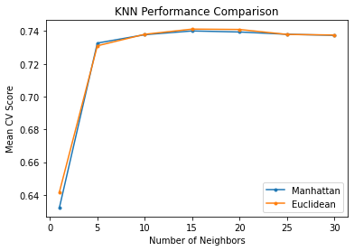

```python
#Plotting the performance of KNN model
for i in ["Manhattan", "Euclidean"]:
    temp = results_KNN[results_KNN['metric'] == i]
    plt.plot(temp['n_neighbors'], temp['test_score'], marker = '.', label = i)

plt.legend()
plt.xlabel('Number of Neighbors')
plt.ylabel("Mean CV Score")
plt.title("KNN Performance Comparison")
plt.show()
```

From the above graph it can be seen that the `Euclidean Distance` has a CV score of **0.74** for **15 neighbors** which is greater comapred to `Manhattan Distance`.

### Decision Tree

For the decision tree classifier the `DecisionTreeClassifier()` function is used. For this `max_depth` and `min_samples_split` are pre-defined and passed to the classifier. The train and test data is then fitted on these parameters. The model evaluation is done using `cv_method()`.

```python
df_classifier = DecisionTreeClassifier(random_state=999)
params_DT = {'max_depth': [3, 5, 7, 10, 12],
             'min_samples_split': [2, 5, 15, 20, 25]}

#Performing Grid Search
gs_DT = GridSearchCV(estimator=df_classifier,
                     param_grid=params_DT,
                     cv=cv_method_train,
                     verbose=1,
                     scoring=scoring_metric)

#Fitting the model on the train sets
gs_DT.fit(D_Train_fs, t_train);
```

```
Fitting 5 folds for each of 25 candidates, totalling 125 fits
```

```python
#Displaying the best parameters
gs_DT.best_params_
```

```
{'max_depth': 5, 'min_samples_split': 20}
```

```python
#Displaying the best score
gs_DT.best_score_
```

```
0.7445113251748336
```

```python
# Let's define a new data frame to store the DT grid search results for visualization.
results_DT = pd.DataFrame(gs_DT.cv_results_['params'])
results_DT['test_score'] = gs_DT.cv_results_['mean_test_score']
results_DT.columns
```

```
Index(['max_depth', 'min_samples_split', 'test_score'], dtype='object')
```

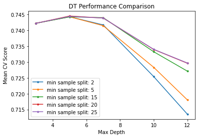

```python
#Plotting the performance of the Decision Tree
for i in [2, 5, 15, 20, 25]:
    temp = results_DT[results_DT['min_samples_split'] == i]
    temp_average = temp.groupby('max_depth').agg({'test_score': 'mean'})
    plt.plot(temp_average, marker = '.', label = 'min sample split: ' + str(i))


plt.legend()
plt.xlabel('Max Depth')
plt.ylabel("Mean CV Score")
plt.title("DT Performance Comparison")
plt.show()
```

From the above plot it cnan be seen that for `min sample split` of **20** has a CV score of **0.744** for **max depth** of **5** which is greater than another sample splits.

### Naive Bayes

The `Naive Bayes` algorithm uses the `GaussianNB()` classifer for fitting the model. Before that `Power Transformation` is applied to the descriptive feautres as the features need to follow the Gaussian Distribution for the implementation of the Naive Bayes algortihm. For this we specify the smoothing parameter which will lie in the logspace of 10 to 10^-2 using the `Grid Serach CV` strategy is used on which the trained data is fitted.

```python
from sklearn.naive_bayes import GaussianNB
from sklearn.preprocessing import PowerTransformer

nb_classifier = GaussianNB()

params_NB = {'var_smoothing': np.logspace(1,-2, num=50)}

#Performing Grid Search
gs_NB = GridSearchCV(estimator=nb_classifier,
                     param_grid=params_NB,
                     cv=cv_method_train,
                     verbose=1,
                     scoring=scoring_metric)
#Applying Power Transformation
D_Train_fs_transformed = PowerTransformer().fit_transform(D_Train_fs)

#Fitting the model on the train sets
gs_NB.fit(D_Train_fs_transformed, t_train);
```

```
Fitting 5 folds for each of 50 candidates, totalling 250 fits
```

```python
#Displaying the best parameters
gs_NB.best_params_
```

```
{'var_smoothing': 0.22229964825261944}
```

```python
#Displaying the best score
gs_NB.best_score_
```

```
0.7307294228664336
```

```python
# Let's define a new data frame to store the NB grid search results for visualization
results_NB = pd.DataFrame(gs_NB.cv_results_['params'])
results_NB['test_score'] = gs_NB.cv_results_['mean_test_score']
```

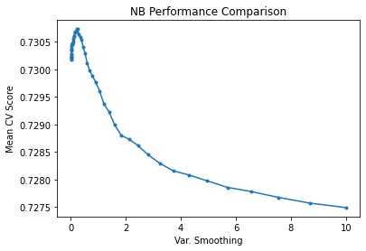

```python
#Plotting the performance of the model
plt.plot(results_NB['var_smoothing'], results_NB['test_score'], marker = '.')
plt.xlabel('Var. Smoothing')
plt.ylabel("Mean CV Score")
plt.title("NB Performance Comparison")
plt.show()
```

From the plot it can be seen that the model has highest CV of **0.7306** smoothing of **0.222**

### RandomForest

The `GridSearchCv` fitting strategy is used for fitting the parameters on the training data.

```python
from sklearn.naive_bayes import GaussianNB
from sklearn.preprocessing import PowerTransformer

rf_classifier = RandomForestClassifier(random_state=999)

#Defining the parameters
params_RF = {'n_estimators': [100, 250, 500],
             'max_depth': [5, 7, 10, 12]}

#Performing Grid Search
gs_RF = GridSearchCV(estimator=rf_classifier,
                     param_grid=params_RF,
                     cv=cv_method_train,
                     verbose=1,
                     n_jobs=-2,
                     scoring=scoring_metric)

#Fitting the model with the train sets
gs_RF.fit(D_Train_fs, t_train);
```

```
Fitting 5 folds for each of 12 candidates, totalling 60 fits
```

```python
#Displaying the best parameters
gs_RF.best_params_
```

```
{'max_depth': 7, 'n_estimators': 250}
```

```python
#Displaying the best score
gs_RF.best_score_
```

```
0.7436961005573999
```

```python
# Let's define a new data frame to store the grid search results for visualization.
results_RF = pd.DataFrame(gs_RF.cv_results_['params'])
results_RF['test_score'] = gs_RF.cv_results_['mean_test_score']
results_RF.columns
```

```
Index(['max_depth', 'n_estimators', 'test_score'], dtype='object')
```

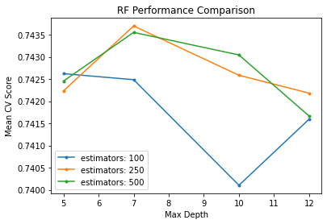

```python
#Plotting the performance of Naive Bayes Model
for i in results_RF['n_estimators'].unique():
    temp = results_RF[results_RF['n_estimators'] == i]
    plt.plot(temp['max_depth'], temp['test_score'], marker = '.', label = 'estimators: ' + str(i))

plt.legend()
plt.xlabel('Max Depth')
plt.ylabel("Mean CV Score")
plt.title("RF Performance Comparison")
plt.show()
```

From the above plot it can be seen that the model has a highes score of **0.7436** for a `max_depth` of **7** for the number of `estimators` of **250**.

## Model Comparison

```python
cv_method_test = StratifiedKFold(n_splits=5, shuffle=True, random_state=999)
```

```python
#Displaying the performance score of KNN model
cv_results_KNN = cross_val_score(estimator=gs_KNN.best_estimator_,
                                 X=D_Test_fs,
                                 y=t_test,
                                 cv=cv_method_test,
                                 scoring='roc_auc')


cv_results_KNN.mean()
```

```
0.7286004386957318
```

```python
#Displaying the performance score of Decision Tree Model
cv_results_DT = cross_val_score(estimator=gs_DT.best_estimator_,
                                 X=D_Test_fs,
                                 y=t_test,
                                 cv=cv_method_test,
                                 scoring='roc_auc')
cv_results_DT.mean()
```

```
0.7605931275538507
```

```python
##Displaying the performance score of KNN model
# Applying Power Transformation to the test set

D_Test_fs_transformed = PowerTransformer().fit_transform(D_Test_fs)

cv_results_NB = cross_val_score(estimator=gs_NB.best_estimator_,
                                 X=D_Test_fs_transformed,
                                 y=t_test,
                                 cv=cv_method_test,
                                 scoring='roc_auc')
cv_results_NB.mean()
```

```
0.7195866333016582
```

```python
##Displaying the performance score of Random Forest Model
cv_results_RF = cross_val_score(estimator=gs_RF.best_estimator_,
                                 X=D_Test_fs,
                                 y=t_test,
                                 cv=cv_method_test,
                                 n_jobs=-2,
                                 scoring='roc_auc')
cv_results_RF.mean()
```

```
0.7523663020019006
```

```python
#create data frame to store cross validation scores for all 4 models
#create first column classifiers_cross_val
classifiers_cross_val_list = ['K-Nearest \nNeighbours', 'Decision\nTree', 'Random\nDecision\nTree', 'Naive\nBayes']

#create second column classifiers_cross_val_value
classifiers_cross_val_list_values = [cv_results_KNN.mean().round(3),
                                     cv_results_DT.mean().round(3),
                                     cv_results_RF.mean().round(3),
                                     cv_results_NB.mean().round(3)]

#create the data frame
df_cross_val = pd.DataFrame(columns = ['classifiers_cross_val', 'classifiers_cross_val_value'])
df_cross_val['classifiers_cross_val'] = classifiers_cross_val_list
df_cross_val['classifiers_cross_val_value'] = classifiers_cross_val_list_values
```

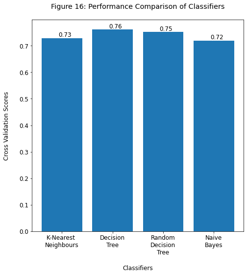

```python
#plot bar chart for cross validation score of all 4 models

fig = plt.figure(figsize = (6, 6))
plt.rcParams.update({'font.size': 12})
ax = fig.add_axes([0, 0, 1, 1])
x = df_cross_val['classifiers_cross_val']
x_pos = [i for i, _ in enumerate(x)]

rects1 = ax.bar(x_pos, df_cross_val['classifiers_cross_val_value'])
plt.xlabel('\nClassifiers')
plt.ylabel('Cross Validation Scores\n')
plt.title('Figure 16: Performance Comparison of Classifiers\n')
plt.xticks(x_pos, x)
for rect in rects1:
        height = rect.get_height()
        ax.text(rect.get_x() + rect.get_width() / 1.75,
                1.00 * height,
                '%.2f' % float(height),
                ha='center',
                va='bottom',
                fontsize='12')

plt.show()
```

From the above plot it can be seen that the `Decision Tree` performs better comapre to the rest of the models into consideration with `Cross Validation Score` of **0.76**

```python
from scipy import stats

# Decision seems to be the best, so let's compare that to the others
# any p-value < 0.05 indicates a statistically significant result

print(stats.ttest_rel(cv_results_DT, cv_results_KNN))
print(stats.ttest_rel(cv_results_DT, cv_results_RF))
print(stats.ttest_rel(cv_results_DT, cv_results_NB))
```

```
Ttest_relResult(statistic=4.681262538789115, pvalue=0.009438844778137221)
Ttest_relResult(statistic=2.0722126150699265, pvalue=0.10696174496760476)
Ttest_relResult(statistic=4.165225469918748, pvalue=0.014085474694720225)
```

From the ttest it can be seen that the p-value is less than 0.05 for 1st and 3rd results showing that there is a significant difference in the results of `Decision Tree` and `Naive Bayes`. However, there is no difference in the results of the `Decsion Tree` and `Random Forest` as the p-value is greater than 0.05 suggesting that the results are insignificant.

```python
#predict target feature for test_data using k-Nearest Neighbours
pred_KNN = gs_KNN.predict(D_Test_fs)

#predict target feature for test_data using Decision Tree
pred_DT = gs_DT.predict(D_Test_fs)

#predict target feature for test_data using Random Forests
pred_RDT= gs_RF.predict(D_Test_fs)

#predict target feature for test_data using Naive Bayes
pred_NB= gs_NB.predict(D_Test_fs_transformed)
```

```python
#Displaying the Confusion Matrix for each model
print("\nConfusion matrix for K-Nearest Neighbor")
print(metrics.confusion_matrix(t_test, pred_KNN))

print("\nConfusion matrix for Decision Tree")
print(metrics.confusion_matrix(t_test, pred_DT))

print("\nConfusion matrix for Random Decision Tree")
print(metrics.confusion_matrix(t_test, pred_RDT))

print("\nConfusion matrix for Naive Bayes")
print(metrics.confusion_matrix(t_test, pred_NB))
```

```
Confusion matrix for K-Nearest Neighbor
[[ 900  398]
 [ 749 1253]]

Confusion matrix for Decision Tree
[[1227   71]
 [1005  997]]

Confusion matrix for Random Decision Tree
[[1215   83]
 [ 983 1019]]

Confusion matrix for Naive Bayes
[[ 962  336]
 [ 836 1166]]
```

```python
#Displaying the Classification Report for each Model
print("\nClassification Report for K-Nearest Neighbor")
print(metrics.classification_report(t_test, pred_KNN))

print("\nClassification Report for Naive Bayes")
print(metrics.classification_report(t_test, pred_NB))

print("\nClassification Report for Decision Tree")
print(metrics.classification_report(t_test, pred_DT))

print("\nClassification Report for  Random Decision Tree")
print(metrics.classification_report(t_test, pred_RDT))
```

```
Classification Report for K-Nearest Neighbor
              precision    recall  f1-score   support

           0       0.55      0.69      0.61      1298
           1       0.76      0.63      0.69      2002

    accuracy                           0.65      3300
   macro avg       0.65      0.66      0.65      3300
weighted avg       0.68      0.65      0.66      3300


Classification Report for Naive Bayes
              precision    recall  f1-score   support

           0       0.54      0.74      0.62      1298
           1       0.78      0.58      0.67      2002

    accuracy                           0.64      3300
   macro avg       0.66      0.66      0.64      3300
weighted avg       0.68      0.64      0.65      3300


Classification Report for Decision Tree
              precision    recall  f1-score   support

           0       0.55      0.95      0.70      1298
           1       0.93      0.50      0.65      2002

    accuracy                           0.67      3300
   macro avg       0.74      0.72      0.67      3300
weighted avg       0.78      0.67      0.67      3300


Classification Report for  Random Decision Tree
              precision    recall  f1-score   support

           0       0.55      0.94      0.70      1298
           1       0.92      0.51      0.66      2002

    accuracy                           0.68      3300
   macro avg       0.74      0.72      0.68      3300
weighted avg       0.78      0.68      0.67      3300
```

From the confusion matrix we want to look at the accuracy and recall values for each of the model . This is so because for out problem , that is to determine if the product is going to reach on time or not the accuracy of the model is on the priority. After that the recall of the model is checked as whenever the model predicts a possitive result we want to know how often it makes a correct prediction. From the above result we can see that the accuracy and recall value of Random Decision Tree or Random Forest classifier has the highest accuracy as well recall score with 1% difference with the Decision Tree model. Using the AUC metric the `Decision Tree` as the best performing model while using the classification report we have got the best performing model as `Random Forest Model`.

# Critique & Limitations

- Since the models are trained only on test size of 70-30, this limits on the results of obtaining a model where all the test size are considered.
- As the paramters are fixed to a limited number of values, the models are not trained on the rest of the parameters which limits on the chances of having a better performing model compared to what has been obtained.
- There are two models that can be taken into consideration which is shown by the cross validation score and the classification report. More anallysis is required for the same.
- There are other efficent strategies for the approach of feature selection that can be done in order to get the best performing model

# Summary & Conclusions

## Project Summary

To give a brief summary of our overall project we started with the data cleaning by dropping the 'Id' column and modifying the target variable to a convenient naming convention from "Reached.on.Time_Y.N" to "Reached_On_Time". In Phase 1 of the project we visualised , one variable, two variable and three variable plots so as to find the correlation between the different features and their association with the target variable. From the heatmap we found that the highest correlation is among the `Discount_offered` and `Reached_on Time`.

Then we split the target variable and other descriptive features into two separate dataframes as the target variable is in the required format and we need not transform it.

For data preparation we used the get_dummies function to encode the categorical features in 1s and 0s format. Next,to transform the values of all the variables on a similar scale i.e between 0 and 1 we used the 'MinMaxScaler' method.The data is now ready for further processing.

Before feature selection we divided the dataset into training and test data where we are considering the test data to be 30% and the training data to be 70%.

`t-test` was performed to find the statistically best performing algorithm using cross validation method with scoring metric as `roc_auc`.It was found that for `KNN` and `Naive Bayes` when compared with `Decision Tree` we got a statistically significant result as the p-value is <0.05 but statistically insignificant result for `Random Forest`.

A comparison bar graph is also plotted to get a clear idea of the comparison along with the confusion matrix and classification report, which gave `Decision Tree` and `Random Forest` as the best algorithm to solve this problem. For our objective we have decided to go forward with both the models as both the models have statistically insignificant results whcih means they are almost the same which can be from the accuracy and recall score which shows 1% difference in their results.

## Summary of Findings

From the results it has been observed that both the `Decision Tree` and `Random Forest/Decision Tree` perform better compared to the rest of the models. However, using the cross validation score the `Decision Tree` seems to be promising while using the classification reprt the`Random Forest` model seems to be promising. This can be resolved with the ttest results of the model comparison. It can be seen that the there is no difference in the results of the `Decision Tree` and `Random Forest` which is show by p-value greater than 0.05. Also, both the models have a difference of 1% in their reuslts which can be ignored. So, for our goal of prediciting the delivery status of product reaching on time both the models `Decision Tree` and `Random Forest` can be used.

# REFERENCES

[1]"E-Commerce Shipping Data", Kaggle.com, 2021. [Online]. Available: https://www.kaggle.com/prachi13/customer-analytics. [Accessed: 30- May- 2021].

[2]"SK Part 2: Feature Selection and Ranking | www.featureranking.com", www.featureranking.com, 2021. [Online]. Available: https://www.featureranking.com/tutorials/machine-learning-tutorials/sk-part-2-feature-selection-and-ranking/. [Accessed: 30- May- 2021].

[3]"SK Part 3: Cross-Validation and Hyperparameter Tuning | www.featureranking.com", www.featureranking.com, 2021. [Online]. Available: https://www.featureranking.com/tutorials/machine-learning-tutorials/sk-part-3-cross-validation-and-hyperparameter-tuning/. [Accessed: 30- May- 2021].

[4]"SK Part 4: Model Evaluation | www.featureranking.com", www.featureranking.com, 2021. [Online]. Available: https://www.featureranking.com/tutorials/machine-learning-tutorials/sk-part-4-model-evaluation/. [Accessed: 30- May- 2021].